# The Use of Explicit Health Benefits Packages Increases Support for Universal Health Care for People with High Objective Numeracy

Sean Xiaohao Duan sxdff5@mail.missouri.edu (University of Missouri, Columbia - Department of Psychology)

# Introduction

Healthcare in the United States is a significant financial burden on the average American. Medical expenses are the top contributor to bankruptcy in America (Himmelstein 2019), and insurance is unaffordable for many Americans, indicated by the fact that 11.1% of the population is uninsured (“Trends in the U.S. Uninsured Population, 2010-2020,” 2021). An additional 21.3% of Americans are underinsured, defined as unsustainable health spending, with 10% of household income going to health costs(Collins 2020). Because healthcare spending is unsustainable for people who are uninsured or underinsured, the majority of this group goes without necessary medical services (Schoen 2005).

The US government also spends an astronomical amount on health care annually, particularly in comparison to peer nations. In 2016, 17.8% of GDP was spent on healthcare, with other with other peer countries spending between 9.6% to 12.4%. Shockingly, the US also has the lowest life expectancy of these countries, 78.8, compared to an average of 81.7 and ranks poorly in most markers of health outcomes (Papanicolas 2018).

One answer to skyrocketing health costs and ineffective outcomes is Universal Health Care (UHC). UHC directly addresses US concerns regarding cost of healthcare, lack of coverage, and poor health outcomes. Cost of implementation temporarily spikes total healthcare spending but has historically resulted in reduced spending later (Hsiao 2016). UHC increases healthcare coverage (Hsiao 2016, Panpiemras et al. (2011), resulting in lower mortality and better overall health in the population (Galvani et al. 2017). While there are clear benefits to UHC in the US, only 28.2% Americans support doing so (Holahan et al., 2019). Thus, increasing the likelihood of implementation by improving support for UHC is valuable. The goal of this project is to examine the interventions designed to increase support of UHC that directly address common reasons for opposition.

## Inadequacies with our current system

The purpose of health care is to improve the well-being of those treated. However, 61% of all debt in America originates from medical costs, with the average American owing $9,374 (Austin, 2014; Schoen 2005). The American health system often worsens the well-being of those treated instead; Medical debtors are 42% more likely to suffer from a lapse in medical coverage (Himmelstein, 2005). This is particularly relevant in the US as some of our most disadvantaged minorities simultaneously suffer from low rates of insurance compared to Whites (11.7% for Whites, 20.8% for Blacks, 30.7% for Hispanics) (Shen et al., 2013). Medical debt is partly due to extreme cost differences in care; The US pays approximately twice as much as peer countries for medical procedures and pharmaceuticals (Anderson, 2003; Papanicolas, 2018; Tikkanen, 2020). This is compounded by unwillingness to ration care and administrative complexity, pushing cost higher with low value outcomes (Reinhardt 2004). The U.S. system of multiple insurers leads to under-investment in preventative care and in medical infrastructure that generates long term value. This is since insurers share the benefits from the cost of implementation with their competitors (Anderson, 2003). The US health system has high waste due to the lack of centralized payment and distribution as well (Shrank 2019). Estimates of waste are nearly $1 trillion, approximately 25% of total health spending. Over 40% of this waste is due to administrative complexity and inflated pricing. Medical care is plainly unaffordable in the United States for many.

Health outcomes in the US are notoriously poor. Life expectancy in the US has not improved since 2014, even as the per capita cost of healthcare has risen from $9,466 to $11,582 (National Health Expenditure Accounts Tables, 2014-2019; Murphy, 2014; Kochanek 2019). This is distressing when we consider that up to 50% the care provided is not evidence based (Manchikanti et al., 2010). Low quality and ineffective pharmaceuticals are distributed more quickly through the US health system compared to peer countries with UHC due to demands for rapid adoption of new treatments, without necessarily proving their long-term efficacy (Kyle, 2017). US healthcare is ranked as low as 15th out of 25 major industrialized countries, due to inflated costs, waste, fraud, and the poorest aggregate utilization of physician visits and hospital days (World Health Report, 2000; Anderson, 2003). The US also falls behind other peer countries on almost every health outcome metric (Tikkanen, 2020). The US has the highest suicide rate with 13.9 per 100,000 versus an average of 11.5. The US also suffers from the highest chronic disease burden (28% of population versus an average of 17.5%) and rate of obesity (40% versus an average of 21%) by far. Lastly, people in the US have the highest rates of hospitalizations and deaths from preventable causes (approximately 50% greater hospitalizations, and 70% greater deaths, than peer-country averages). While the US spends the most in both percentage of GDP and total expenditure on healthcare by a significant margin, our health outcomes are uniformly worse than peer nations.

## Benefits of Universal Health Care

A resolution adopted by the UN General Assembly states that UHC is “access to key promotive, preventive, curative, and rehabilitative health interventions for all at an affordable cost” (Assembly, 1991). The most obvious benefit of UHC is that it leads to improvement in coverage. In Thailand and Taiwan, within one year of implementation of UHC, insurance coverage surged from less than 57% to over 97% (Panpiemras et al., 2011;Hsiao, 2016). This improvement in coverage is vital. In the US, the uninsured and underinsured are between 25-40% more likely to die, leading to 44,000 deaths per year, rivalling the impact (42,000 deaths) of kidney disease (Franks 1993, Wilper 2009). Neonates are especially at risk, with lack of insurance increasing the risk of death by 260%, more than being born with congenial malformation (Morriss 2013). In general, by improving coverage, population health improves.

Furthermore, UHC can improve health outcomes through avenues other than increased coverage. A UHC system allows for centralization of control and information. During both the 2003 SARS epidemic and the 2009 H1N1 outbreak in Taiwan, automatic reporting and contact tracing integrating the travel and healthcare systems allowed for simple and effective contact tracing (Hsiao, 2016). Greater proportions of public health spending versus private health spending have also been shown to enhance overall health in 17 peer countries (Kim, 2013). Each percentage increase in public expenditure reduces infant mortality by 0.077% and increases life expectancy by 0.026 years. UHC is a functional way to increase the proportion of public health spending.

In addition to improving coverage, quality of healthcare, and health outcomes, UHC is also effective at reducing waste and costs in healthcare. A 30-year examination of peer countries that implemented a single payer system (controlling for health status, demographics, level of preventative medicine, and political factors) showed a difference in cost of .75% of GDP, estimated at 150$ billion per year in the US (Bichay, 2020). Half of the saved cost is due to reduced cost of medical goods and administrative spending (0.37% GDP) and most of the rest is due to improved health outcomes (0.2% GDP). Current waste in the US system due to administrative costs could be reduced by 33-53% with the adoption of UHC (Scheinker, 2021). Moreover, centralization due to UHC allows for savings from improved information aggregation and analysis. The Taiwanese National Healthcare Insurance Administration has used statistical modeling to identify outlier health providers, leading to an 8% reduction in expenditures within their first two years of operation by controlling fraud and abuse (Hsiao, 2016). Additionally, while the US uses 10% fewer drugs per capita than other peer countries, prices are 50% higher for equivalent drugs (Manchikanti, 2009). An extreme example can be found when looking at recent price spikes in the US for toxoplasmosis drugs (a 5,500% increase) and EpiPens (a 791% increase), which did not occur in Europe or Canada. Countries implementing single-payer systems have lower average pharmaceutical costs, due to lower pharmaceutical prices and prioritization of effective generic alternatives to expensive brand-name drugs (Morgan, 2017). By creating a functional single buyer market, UHC is effective at limiting aggregate costs across the board in both healthcare goods and technologies (Hussey, 2003).

## Opposition and Support to Universal Health Care

One source of opposition to UHC in the United States is due to difficulties understanding UHC. In Americans that oppose UHC, approximately half were unable to understand the structure of the Affordable Care Act (ACA) or its component pieces (Barcellos 2013; Kaiser Family Foundation Health Tracking Poll 2011). Furthermore, misinformation regarding UHC is extremely common, as over 60% of Americans cited television as their primary source of information about the ACA (a step towards UHC). Plainly untrue statements were propagated, such as calling the ACA “socialism” or “a seizure of one sixth of the economy” (Skidmore, 2012). Television advertisements originating from Republican candidates in 2012 and 2014 painted an immensely negative picture of UHC, which was possible in part due to lack of information (Dalen 2015).

A study by Huebner and colleages (2006) found that U.S. medical students struggled to come to consensus on terms related to UHC such as “fee for service,” “single-payer,” and “universal health care.” This illustrates difficulty in understanding UHC. The authors also note that they were not able to define ‘complex policy terms’ in the questionnaire, indicating a need to explain UHC in a simpler fashion. Academic understanding and analysis of UHC has also been harmed due to a lack of a shared etymology (Hsiao 2016). Additionally, belief that UHC would make the healthcare more comprehensible is strongly correlated with willingness to support UHC (Holahan 2019). 89.4% of those that support UHC believe that UHC would make health care simpler and easier, where only 50% of those that oppose UHC believe the same.

Knoll and colleagues (2015) have found that increased saliency and belief in ‘Nativism,’ defined as the perception that foreign influence despoils traditional American heritage, predicts opposition to health care reform. Surprisingly, this holds true for both Republicans and Democrats. Additionally, this was after controlling for partisanship, ideology, and racial resentment, which all had independent significant effects on support for health care reform. The total effect was that strongly nativist beliefs lead to a 35.5% reduction in belief that health reform was at least favorable or ambivalent, compared to those with strongly non-nativist beliefs.

Another common source for opposition to UHC in the US is the perception that UHC is inequitable. Belief that UHC would lead to equitable coverage is strongly correlated with support for UHC. 91% of those that support UHC believe that equitable coverage is important, while only 45% of those that oppose UHC believe the same (Holahan 2019). Furthermore, when Shen and colleagues (2016) examined the impact of racism on support for UHC, they found that perceived inequity was the mechanism through which racism impacted support for UHC. The authors hypothesized that Whites opposed government programs designed to eliminate racial inequity because it constituted unjust government assistance. While UHC is not designed to specifically benefit Blacks, individuals harboring racist beliefs may assume that is the case. Crucially, whether the individual purported to benefit from UHC was a ‘free-rider’ (inequitably benefitting from UHC) was what predicted opposition to UHC. This was unrelated to race.

However, racial disparities do indeed exist regarding support for healthcare reform (Byrd et al., 2011). A larger proportion of Blacks (78.6%), Latinos (52.6%), and other minorities (43.6%) supported health reform compared to Whites (38.4%). Previous literature also indicates that Blacks and Whites have different perceptions on whether race affects individual health outcomes, with over half of Blacks believing that race impacts individual health outcomes, and over half of Whites having no opinion or believing the opposite (Lillie-Blanton et al., 2000). This illustrates the importance of perceived equity on support for UHC. Determining how address both perceptions of equity and develop an accurate understanding of UHC to improve support is a challenge.

## Previous US Attempts towards UHC

There have been several attempts to implement UHC in the United States at the state level (e.g., California, Washington, Florida, etc.); however, none have been successful to date. In 2011, the local legislature in the state of Vermont enacted a bill guaranteeing UHC for all Vermont residents (State of Vermont Health Care Financing Plan Beginning Calendar Year 2017 Analysis, 2013). This bill, known as “Green Mountain Care,” was seen as both a tool to improve health outcomes in Vermont and a way to reduce medical costs and strengthen the economy. Three different independent organizations projected this to be the case, with a consensus that immediate healthcare costs for Vermont would be lowered by 8-12% and another 12-14% over the next 10 years (Hsiao, 2011; Green Mountain Care Financing Report, 2014; State of Vermont Health Care Financing Plan Beginning Calendar Year 2017 Analysis, 2013). Combined with the fact that cost increases were estimated to be only 9.4% for employers and 3.1% for individuals, total savings across the system were estimated to be $378 million over 5 years. Difficulties arose in implementation however, due to a combination of reduced federal revenue and increased scope of coverage to nonresidents working in Vermont (McDonough 2015). The plan was eventually abandoned in 2014, due to proportionally larger taxes on business and difficulty in communicating the benefits arising from elimination of current premium costs (Fox 2015). The public was hyper-aware of the tax raises necessary to implement the program, but Vermonters did not receive clear messaging on the net savings that would result from replacing current premiums with a tax raise.

Oregon is another state where UHC expansion has been debated and examined. The Oregon Medicaid lottery in 2008 was the first time in the US where a randomized controlled study on UHC was possible. Data from roughly 6,000 adults who were selected to apply for Medicaid, and 6,000 who were not, allowed for objective evaluation (Baicker, 2013). Researchers found no significant improvements over a two-year period in direct measurements of health, such as blood pressure, cholesterol, blood sugar, tobacco use, or obesity (James 2015). However, significant benefits arose in the form of greater management for continuing conditions, lower depression, and most significantly, an almost complete elimination of catastrophic out of pocket medical expenses, leading to lower medical debt. The primary concern from critics were concerns that many objective physical health outcomes saw no improvement, and that while self-reported health did show significant improvement, it was less important given the inherent noise in self-reported data. Given these concerns, UHC was seen as politically infeasible, even though 62% of Oregon voters would “definitely” or “probably” support a UHC plan that would double or triple state taxes (Rosenberg 2020).

## Health Benefits Packages

Interventions specifically attempting to directly improve support for UHC have not previously been examined in the literature. A potential intervention that would directly address US concerns towards UHC would be to present UHC within the framework of a Health benefits package (HBP). A HBP is defined by three factors (Glassman et al., 2016). First, HBPs are a comprehensive portfolio of services (e.g., dental, mental health, pharmaceuticals) as compared to programs that only cover a single service (e.g., GoodRx and pharmaceuticals). This allows assessment of cost effectiveness by directly comparing different services to one another. Second, HBPs are designed and priced using actuarially informed estimates of supply and demand. Third, HBPs constrain the services made available through the public health system, but by doing so, guarantee that at least certain services will be made available.

In the American system of health care, many experts agree that efficiency and quality of care are unlikely to be improved without an HBP like system, combining a well-defined framework with the legal specificity necessary for regulation (Chalkidou, Marquez, and Dhillon et al., 2014). As HBPs create explicit entitlements for patients, they reduce confusion as to what is being offered. Furthermore, HBPs help ensure fairness and equity by preventing discretionary variation in access to care that would otherwise be largely determined by clinical professionals. In countries with UHC without an HBP linked to cost, there are significant gaps in coverage, implicit rationing, and consequently lower quality healthcare outcomes (e.g., higher infant mortality, greater spread of communicable disease). For example, Uganda has intended to guarantee UHC to all citizens since 1999 (Odokonyero et al., 2017). However, by 2017, only 52% of their poorest, and 69% of their wealthiest citizens had coverage. Inefficient concentration of resources in urban areas lead to implicit rationing of comprehensive coverage for most Ugandans, living in rural areas without easy access to transportation. Another parallel can be found in Ghana’s National Health Insurance Scheme (Agyepong et al. 2016). Implemented in 2003 to provide UHC, by 2016 only 40% of the population had coverage. Critically, enrollment stagnated due to citizen unhappiness with the system; Concerns included frequent stock-outs of pharmaceuticals, unequal enforcement of regulations, and the perception that certain minority groups benefited inequitably. Clear evidence exists that lacking an HBP in several countries has resulted in an ineffective attempt at achieving UHC, both in citizen perception, and wholeness of coverage.

Conversely, countries that have UHC with an HBP are perceived as well functioning. 78% of Swiss citizens surveyed perceived their HBP based system as one that is fair for the ill, due to a combination of appropriate levels of coverage, equal protection to all Swiss citizens, and increased knowledge about the health system (Hurst 2018). As another example, when a HBP was used to examine different configurations of Medicare benefits in the U.S., 83% of studied enrollees agreed that the consensus plan provided was fair (Danis 2004). Furthermore, 66% agreed strongly, and a further 30% agreed somewhat that the HBP was easy to understand. Most importantly, 86% of participants believed that the presented HBP was one they were satisfied with. Presenting otherwise complex trade-offs of health benefits in a simple, easy to understand fashion was extremely beneficial.

Emphasizing the necessary nature of tradeoffs or compromises in medical care and doing so in a clear and easy to understand way is vital. Developed by Goold and colleagues (2000), the Choosing Healthplans All Together intervention explains HBPs clearly by directly addressing these concerns. The central tenet of the CHAT exercise is for participants to construct their own HBP by allocating a limited set of resources to benefit types (e.g., dental, fertility treatments, long-term care) and choosing scope of coverage (e.g., generics instead of name-brand drugs, amount of copayments, etc.). The purpose of the exercise was initially to help explain how trade-offs in medicine are necessary, as well as to determine what the subjects prioritize in healthcare given limited resources. The final chosen plan is clear and explicit in types of care and intensity of treatment available, neatly addressing consumer confusion.

The CHAT exercise has been a success, with over 95% of participants finding the task easy to do across several different implementations of the exercise (Danis, Biddle, and Goold, 2002; Danis,2002; Danis, 2004). CHAT has also been adapted twice to explore trade-offs in specific government funded health plans. First, Danis and colleagues (2004) used the CHAT framework to illustrate the financial constraints of government funded Medicare and to assist Medicare enrollees in developing a consensus on what services they want to prioritize. Participants first individually went through the CHAT exercise, then were grouped with approximately 12 participants each; These groups engaged in CHAT, with options being decided by simple majority votes, to reach a consensus HBP. While 41% of participants felt that the HBP designed as a group was different than what they would have chosen for themselves, 86% were still satisfied with the HBP they developed. The second adaptation, by Hurst, Schindler, and Goold (2018), was used to examine how Swiss citizens would prioritize types of care in the already extant Swiss HBP based UHC system. The participants had no trouble using the exercise to improve their understanding of the Swiss HBP, were easily able to make trade-offs and set priorities, and found that they were able to reach a strong consensus. This was exceptionally valuable due to the diversity of opinions observed in the study.

It is important to note that the CHAT exercise is particularly valuable because it is a hands-on exercise as compared to a simple informational intervention. Work by Wegier and colleagues (2019) found that a simulated experience led to more accurate understanding of information as compared to simply being given explicitly described statistics. Furthermore, active instruction is particularly time efficient and engaging when learning complex, numeracy-focused material (Haidet, 2004). Active instruction is also particularly effective at improving subject-specific knowledge gains (Michel, 2009). These characteristics are an ideal match for the material presented in an HBP. Thus, it is reasonable to believe that active instruction will be more effective than a simple ‘fact sheet’ for an HBP that would otherwise be presented to the public.

## The Present Research

The goal of our two studies is to determine whether exposure to UHC through the framework of an HBP can improve support for UHC. Based on previous research, we know that UHC is likely to benefit the US if implemented, and that HBP directly addresses some of the primary reasons that are foundational to opposition of UHC. Regardless, no direct research has been done previously on the effects of HBP on UHC.

# Method

## Participants

| **Characteristic** | **Active Intervention**, N = 60<sup>1</sup> | **No Intervention**, N = 62<sup>1</sup> | **Passive Intervention**, N = 63<sup>1</sup> | **p-value**<sup>2</sup> |
| --- | --- | --- | --- | --- |
| Age | 18.55 (0.70) | 18.44 (0.93) | 18.37 (0.63) | 0.13 |
| Sex |  |  |  | 0.7 |
| Female | 36 / (60%) | 41 / (66%) | 42 / (67%) |  |
| Male | 24 / (40%) | 21 / (34%) | 21 / (33%) |  |
| Race |  |  |  | >0.9 |
| Caucasian/White | 46 / (77%) | 49 / (79%) | 48 / (76%) |  |
| African-American/Black | 5 / (8.3%) | 5 / (8.1%) | 6 / (9.5%) |  |
| Asian/Pacific Islander | 3 / (5.0%) | 3 / (4.8%) | 3 / (4.8%) |  |
| Caucasian/White,Asian/Pacific Islander | 2 / (3.3%) | 4 / (6.5%) | 1 / (1.6%) |  |
| Caucasian/White,African-American/Black | 1 / (1.7%) | 1 / (1.6%) | 1 / (1.6%) |  |
|  | 2 / (3.3%) | 0 / (0%) | 0 / (0%) |  |
| Other | 1 / (1.7%) | 0 / (0%) | 1 / (1.6%) |  |
| African-American/Black,American Indian/Alaska Native | 0 / (0%) | 0 / (0%) | 1 / (1.6%) |  |
| African-American/Black,Hispanic/Latino(a) | 0 / (0%) | 0 / (0%) | 1 / (1.6%) |  |
| Hispanic/Latino(a) | 0 / (0%) | 0 / (0%) | 1 / (1.6%) |  |
| School Year |  |  |  | 0.2 |
| Freshman | 47 / (78%) | 52 / (84%) | 53 / (84%) |  |
| Sophmore | 8 / (13%) | 6 / (9.7%) | 8 / (13%) |  |
| Junior | 5 / (8.3%) | 1 / (1.6%) | 2 / (3.2%) |  |
| Senior | 0 / (0%) | 3 / (4.8%) | 0 / (0%) |  |

<sup>*1*</sup> Mean (SD); n / (%) <sup>*2*</sup> Kruskal-Wallis rank sum test; Pearson's Chi-squared test; Fisher's exact test

## Measures

Participants also responded to several items about their experience with health. Participants were asked whether they paid for their own health insurance and if they had ever been uninsured. Participants in the active intervention condition were also asked if they would be happy having the plan they built as their own health insurance. Each of these three items was measured as a ‘yes’ or ‘no’ response. Additionally, there was a free-response question asking about the subjects thoughts about the exercise they just completed. Finally, we also measured demographic information, including gender identity, age, race/ethnicity, and year in school.

## Power and Statistical Analyses

Additionally, we fitted Bayesian linear multivariate multilevel models to our support for UHC outcome variable as a function of dummy-coded factors ‘condition’ (reference level ‘control’), and ‘time’ (reference level ‘pre’) as well as the ‘condition x time’ two way interaction using the Stan modeling language and the R package brms. Condition, time, and their interaction were our fixed effects, with a random intercept for subjects as our random effect. Our priors were a normal distribution with a mean of 0 and a standard deviation of 2.5 for the mean of our reference levels for our three fixed effects. We used the brms package’s default priors for standard deviations of our random effects (Student’s t-distribution with nu = 3, mu = 0 and sigma = 20), as well as for correlation coefficients in interaction models.

## Study 1 Hypothesis:

Hypothesis 1 – The experimental groups will differ in support for UHC.

> H1a: Participants in the two intervention conditions will have greater increases in support for UHC compared to those in the control condition. We believe this to be the case due to HBPs directly addressing several common sources for opposition to UHC.

> H1b: Participants in the active intervention condition will have greater increases in support for UHC than participants in the passive intervention condition. We believe this to be the case as previous research indicates that complex, subject specific, numerical information is more easily learned through active engagement with the material.

# Results

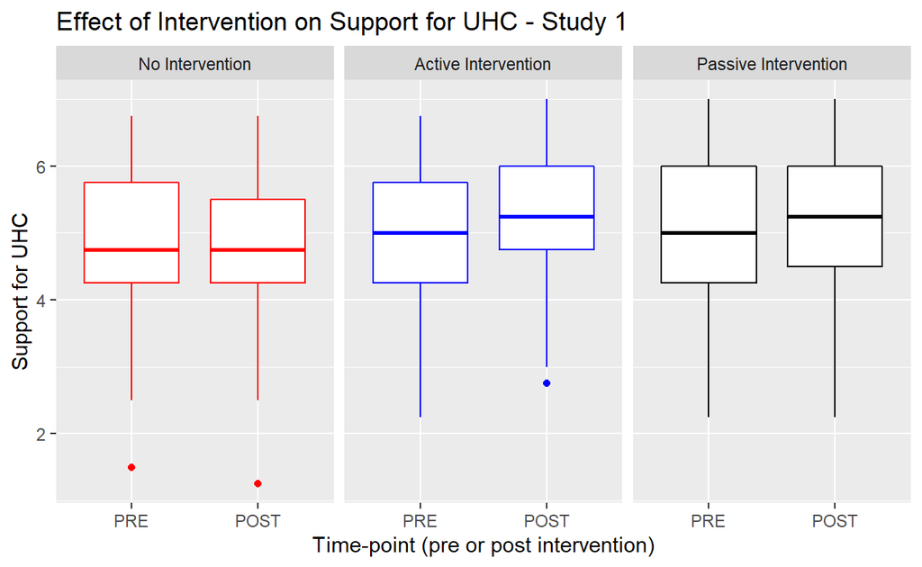

(#fig:study1_plot1)Boxplot showing effect of interventions on support for UHC

## Qualitative results

Analyzing our free-response question, we found several positive and negative trends in our findings. Some participants felt that the pencil and paper exercise was unnecessarily complex, and that the process of completing it was not self-explanitory. Several occasions occurred wherein the participant asked the administrator how to complete the exercise, after having read through the instructions. In total, 10% of participants expressed some form of confusion in their free response segment, e.g. > “It was a little confusing if you aren’t very familiar with insurance and health care.”

> “The way that plan was laid out with the pegs was slightly confusing and I think that it might provide more accurate answers if it were formatted more clearly. Otherwise, I thought that the different levels of care were described well and gave a good picture of what would be provided.”

However, a larger proportion of our participants also found the exercise particularly engaging, interesting, fun, and helpful. In total, 32% of participants expressed some form of positive engagement with the intervention conditions in their free response segment, e.g.

> “I think that is was a good exercise to see what kind of benefits you would want and think about what benefits other people should have also”

> “It was fun trying to make those decisions. I ended up not bubbling any of the ‘long term’”retired person" options because I just don’t care enough for those benefits. Maybe it’s because I’m not in that situation yet.”

We did not predict a priori that our intervention conditions would increase confusion. Nonetheless, an even larger contingent of our participants expressed positive feelings regarding the exercise. Given that the purpose of the interventions were to increase engagement with the often-times boring information necessary to explain UHC, our qualitative data indicates a positive outcome.

# Discussion

One plausible explanation regarding our conflicting results is the confusion regarding the experimental procedure and materials for participants in our active intervention condition. Primarily, our qualitative free-response section indicated that a significant portion of participants in our active intervention condition did not fully understand the instructions necessary. Considering the complexity and numerical engagement necessary to participate, a lack of understanding could plausibly blunt the impact of the intervention. Furthermore, if participants in our active intervention exhibited confusion, while participants in our passive intervention did not, as they had much simpler instructions, that would be a confounding variable when attempting to determine if active instruction is superior for communicating on UHC as compared to passive instruction.

A significant portion of our participants had expressed difficulties with the experimental protocol and materials. This adds avoidable stochasticity to our data and hinders reproducibility. Therefore, the single largest priority in moving from Study 1 to Study 2 was improving the experimental design and materials. Executing a pseudo-replication of the study, with a protocol that is designed to reduce confusion would significantly reduce potential confounding variables. Additionally, our control condition in Study 1 was an uninformative control, which is not necessarily a realistic comparison point regarding commonly available information on UHC. Thus, the second priority was to alter our control condition to reflect the messaging more accurately on UHC that is already available to improve external validity.

# Method

## Participants

| **Characteristic** | **Control**, N = 195<sup>1</sup> | **Intervention**, N = 217<sup>1</sup> | **p-value**<sup>2</sup> |
| --- | --- | --- | --- |
| Age | 18.68 (1.75) | 18.84 (2.08) | 0.3 |
| (Missing) | 1 | 2 |  |
| Gender |  |  | >0.9 |
| Female | 127 / (66%) | 146 / (68%) |  |
| Male | 64 / (33%) | 68 / (31%) |  |
| Gender Variant/Nonconforming | 2 / (1.0%) | 2 / (0.9%) |  |
| (Missing) | 2 | 1 |  |
| Race |  |  | >0.9 |
| White | 153 / (78%) | 161 / (74%) |  |
| Black | 14 / (7.2%) | 16 / (7.4%) |  |
| APAC | 7 / (3.6%) | 10 / (4.6%) |  |
| Other | 4 / (2.1%) | 7 / (3.2%) |  |
| White,Black | 3 / (1.5%) | 6 / (2.8%) |  |
| White,Hispanic/Latino | 2 / (1.0%) | 5 / (2.3%) |  |
| White,APAC | 3 / (1.5%) | 3 / (1.4%) |  |
| Hispanic/Latino | 2 / (1.0%) | 3 / (1.4%) |  |
| White,American Indian/Alaska Native | 2 / (1.0%) | 3 / (1.4%) |  |
| APAC,Hispanic/Latino | 1 / (0.5%) | 1 / (0.5%) |  |
| APAC,Other | 1 / (0.5%) | 0 / (0%) |  |
| Black,American Indian/Alaska Native | 0 / (0%) | 1 / (0.5%) |  |
| Black,Hispanic/Latino | 0 / (0%) | 1 / (0.5%) |  |
| White,Black,American Indian/Alaska Native,Hispanic/Latino,Other | 1 / (0.5%) | 0 / (0%) |  |
| White,Black,APAC | 1 / (0.5%) | 0 / (0%) |  |
| White,Other | 1 / (0.5%) | 0 / (0%) |  |
| School Year |  |  | 0.027 |
| Freshman | 152 / (78%) | 154 / (71%) |  |
| Sophmore | 24 / (12%) | 41 / (19%) |  |
| Junior | 11 / (5.6%) | 19 / (8.8%) |  |
| Senior | 7 / (3.6%) | 1 / (0.5%) |  |
| Other | 1 / (0.5%) | 2 / (0.9%) |  |

<sup>*1*</sup> Mean (SD); n / (%) <sup>*2*</sup> Wilcoxon rank sum test; Fisher's exact test

## Measures

Our secondary outcomes were our proposed mediating factors, perceived equality, and comprehensibility, measured both pre and post-test. Perceived equality was a single item measure adapted from Netemeyer, Boles, McKee, and McMurrian (1997) (‘Universal Health Care provides fair and equitable care to all US citizens, regardless of employment status’). The original item measured fairness in reward allocation, in an industrial/ organizational context relative to amount of responsibilities and work. Our adaptation inquires instead about the fairness in the reward analogue of universal healthcare, relative to type and/or amount of employment. Our measure of comprehensibility was adapted from the perceived complexity measure developed by Mulken, Pair, and Forceville (2010). This scale comprised of two items measuring comprehensibility, which are averaged together (‘Universal Health Care is straightforward, ‘Universal Health Care is easy to understand’). The original item measured perceived complexity and comprehensibility in an advertising context, operationalizing the terms by simply asking if the concept is straightforward to easy to understand. Cronbach’s alpha for the items in our measure of perceived complexity was 0.92.

Our moderating variables were subjective and objective numeracy. Objective numeracy was measured using the Rasch Numeracy Scale, created by Weller et al. (2013). This measure consists of 8 items, all math problems of varying complexity, requiring some amount of algebra, percentiles, and table reading skill (e.g. “If it takes five machines 5 minutes to make five widgets, how long would it take 100 machines to make 100 widgets?”). This measure was scored from 0 to 8, with the sum of all correct answers to the individual items as the subject’s objective numeracy score . The Cronbach’s alpha for these items is 0.71 . Subjective numeracy was measured using the Subjective Numeracy Scale created by Fagerlin et al. (2007). This measure is an average eight items Likert-scale items that range from 1 (generally poor with numbers) to 7 (generally prefer numbers) (e.g. “How good are you at calculating a 15% tip?”). The Cronbach’s alpha for these items is 0.84. Additionally, we did not initially collect data on subjective and objective numeracy until part-way through the data collection. Thus, the first 68 subjects do not have this data recorded.

Participants were then asked whether they paid for their own health insurance and if they have been uninsured, and the active intervention condition was asked if they would be happy having the plan they built as their own health insurance. Each of these three items was measured as a ‘yes’ or ‘no’ response. Additionally, there was a free-response question asking about the subjects’ thoughts about the exercise they just completed. Finally, we also measured demographic information, including gender identity, age, race/ethnicity, and year in school.

## Power and Statistical Analyses

We planned to recruit 176 participants. Sample size was determined a-priori using G-power with the following parameters: greater than 90% power to determine a significant large-sized effect (Cohen’s f =0.10) at an alpha level of .05, for a linear multiple regression. Our support for UHC outcome was treated as a continuous variable. We examined the effects of experimental condition (intervention condition and control condition ), time of intervention (pre vs. post), subjective numeracy, and objective numeracy on our outcome variable by conducting a series of analysis of variance tests. We examined the main effect and the 2-way interactions of condition x time, time x numeracy, and condition x numeracy of our four predictors. Additionally, we also tested models with random and fixed intercepts, with participants being treated as the random effect. Fixed effects comprised of the effect of the experimental condition and time of intervention (pre vs post). All tests were conducted in R and were considered statistically significant when P < .05. Lastly, for our mediational hypothesis, we utilized the bootstrapping method outlined by Tingley and colleagues (2014), to estimate the effect of our proposed mediational variables on support for UHC in the population.

## Study 2 Hypothesis:

Hypothesis 1 – Participants in the intervention condition will have greater increases in support for UHC compared to those in the control condition.

Hypothesis 2a – Differences in support for UHC due to our intervention are partially mediated through perceived equity.

Hypothesis 2b – Differences in support for UHC due to our intervention are partially mediated through comprehensibility.

Hypothesis 3 – Differences in support for UHC due to experimental group assignment are moderated by subjective numeracy and objective numeracy.

# Results

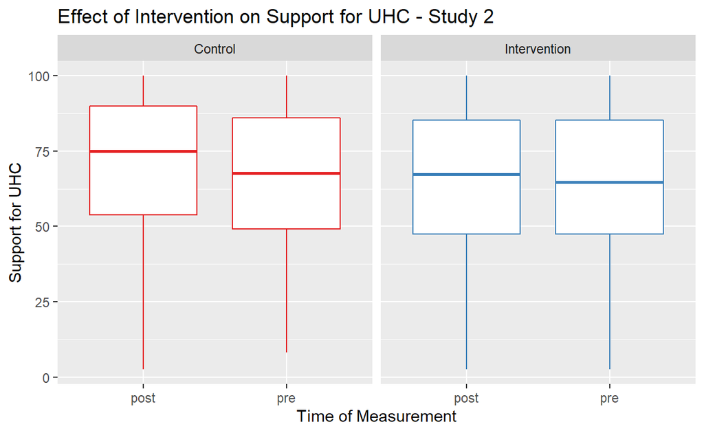

## Proposed Mediational Effects

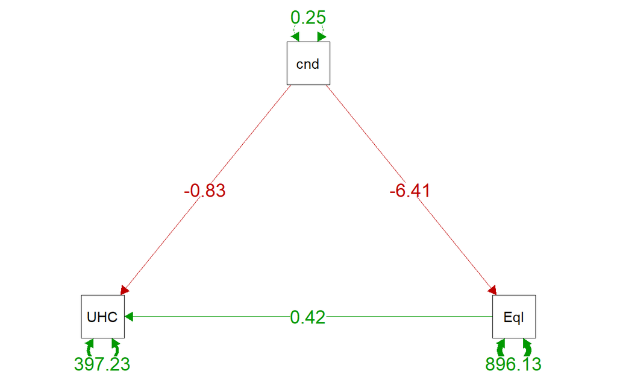

(#fig:path_dia_equity)Path Diagram showing the effect of condition on UHC Support and Percieved Equity

## Moderating Effect of Numeracy

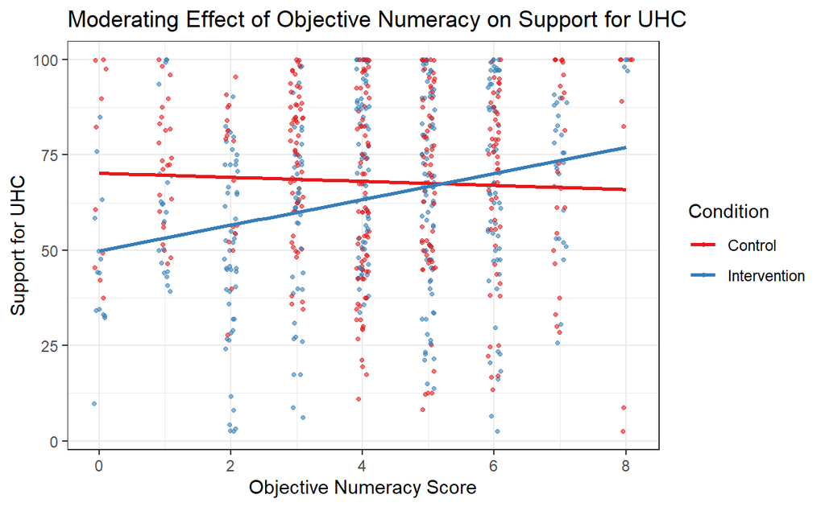

(#fig:study2_plot2)We see a clear interaction between objective numeracy and the intervention

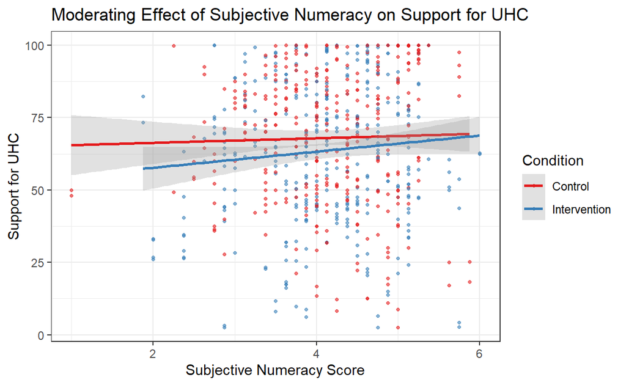

(#fig:study2_plot3)We see no interaction between subjective numeracy and the intervention

## Qualitative results

Analyzing our free-response question, we found very similar responses to those in Study 1, but with some significant differences . Unlike Study 1, no participants reported difficulty with comprehending the new activity or confusion regarding the instructions and procedures.. Several participants however reported difficulty regarding the decision making required in the task itself. Some examples include:

> “it was much more difficult than I thought it was going to be; I had to compromise points in some places to be able to get at least basic coverage in other areas”

> “It’s hard for me to think about people having to pick and choose which parts of healthcare they’ll have access to when they’re all important. It makes me wish healthcare would be reformed for the good of everyone and not just those who can afford it.”

Additionally, replicating what we found in Study 1, 18.4% of intervention condition participants and 8.7% of control condition participants found the activity particularly interesting and fun. Given that the purpose of the intervention is to increase engagement, this is a positive outcome. An example of these responses:

> “Interesting that my answers changed. I would be interested in seeing someone against Universal Health Care make a study, too.”

> “Enjoyed it, overall I believe that there should be Universal Health Care, but I did not realize how complicated it was. This exercise showed me how complicated it will be if the US decides to go through with something like this.”

# Discussion

Our primary goal for Study 2 was to provide a pseudo-replication of our Study 1 hypothesis, with improved experimental materials intended to reduce confusion. Hypothesis 1 was not supported by the results of our intervention. We recorded the exact opposite effect; our intervention was less effective at increasing support for UHC than our control. Additionally, we directly measured our two proposed mediating relationships through Hypothesis 2. We believed that greater perceived equity would increase support for UHC (H2a). We also believed increased comprehensibility would increase support for UHC (H2b).

Hypothesis 2a was supported by the results of our intervention. The data indicated that perceived equality was a significant mediator for support for UHC. Using the bootstrapping method outlined by Tingley and colleagues (2014), we estimated that perceived equality is a significant mediator on support for UHC not just in our sample, but in the population. Our intervention condition was perceived to have lower equity than our control, which partly explains why our control condition had a greater increase in support for UHC, in opposition to Hypothesis 1. Hypothesis 2b was not supported by the results of our intervention; There was not a significant effect of experimental condition on comprehensibility. Lastly, we intended to determine if objective and subjective numeracy would moderate the effect of intervention condition on support for UHC in Hypothesis 3. Hypothesis 3 was partially supported by the results of our intervention. We saw a significant effect of objective, but not subjective numeracy, on support for UHC. Furthermore, we found a significant interaction between the effect of objective numeracy and our intervention condition. Subjects low in objective numeracy had greater support for UHC in our control condition compared to our intervention condition, in opposition to Hypothesis 1. Yet subjects high in objective numeracy had greater support for UHC in our intervention condition compared to our control condition, in support of Hypothesis 1. This indicates that our initial Hypothesis 1 is valid, but only for subjects with higher objective numeracy.

In line with previous research, we did find that the majority (69% of our subjects) of our participants found the HBP acceptable (Goold et al., 2000; Danis et al., 2004). We also replicated the positive level of support found by Huebner et al. (2006), but in a non-medical student population. However, we only partially replicated previous work on the effects of active versus passive instruction (Haidet et al., 2004; Michel et al., 2009; Weiger et al., 2019). We found that active learning was more effective, but only for subjects with higher numeracy. Hadiet and colleagues (2004) found that active instruction was effective for mathematically focused content, we believe that this is due to high objective numeracy further improving the effect of active instruction. The large advantage that the more numerate have is exacerbated even further by active instruction using numbers. Addressing the lack of impact for low-numeracy subjects is necessary to bridge the understanding gap created by the high complexity of UHC.

We had no a-priori assumptions regarding the impacts of numeracy. Peters (2020) writes that objective numeracy measures the ability to use knowledge of basic probability and mathematics, as well as to communicate and interpret mathematical information. In comparison, subjective numeracy represents confidence in ability to understand mathematics, and the preference for numbers over words. Plausibly, those who lack objective numeracy, may find it difficult to engage in calculating and trading off options. Alternatively, more numerate individuals could engage more in a numbers-based activity, paying more attention and thus resulting in a larger effect.

In our intervention, the main source of difficulty was ‘agonizing’ over distribution of resources for an ideal health plan. This is intentional, making realistic and difficult choices akin to those for health-care officials is the purpose of the exercise. Additionally, many individuals in our intervention condition expressed support and appreciation for the exercise. This provides further evidence that the HBP based active intervention was indeed successful at improving engagement. However, one consistent category of responses across both conditions expressed belief that the exercise was either politically motivated or had a strong intentional bias in its construction. To address this, we could present a HBP for a UHC in comparison to a set of standard private insurance plans. Additionally, measuring political affiliation could allow us to directly examine the effect of political motivation on support for UHC.

# Limitations

Study 2 recruited participants from a large midwestern university located in a medium sized midwestern city. This limits the amount of generalization to other populations. The design of Study 2 required familiarity with internet and online survey platform technology, which may make it difficult to adapt to older or less tech-savvy populations. Some subjects indicated in the free-response section that the information presented was biased towards support for UHC and did not paint the whole picture of arguments supporting our current private care system. Therefore, we were unable to derive potential insights comparing to see if positive messaging on private health care would reduce support for UHC.

# Future Directions

The lowest-hanging fruit is a replication of the study, providing evidence of our proposed mediating relationship and moderating effects, on a group that more closely mimics the insurance buying public. This would provide additional external validity, as the primary decision-makers around health insurance are not university students. Another extension for replications of this research would be to developing a structured plan for qualitative analysis such as semantic text analysis, LIWC specifically.

There are several modifications of the experimental materials that would be of interest to examine. One would be determining if different resource availability would have greater or lesser support. If there is no significant difference, that would perhaps provide evidence indicating that the structure of an HBP could have has greater salience in determining approval versus simply the objective healthcare options available.

Another valuable extension would be to measure additional moderating variables. Political orientation and polarization are two variables explicitly referenced in our free response section by participants. We could also design experimental material that explicitly promotes ‘standard’ private health insurance as it exists in the US or compare to negative messaging on ‘standard’ private health care without having positive information about UHC.

The most valuable extension would be to determine how to increase support for UHC with individuals that have lower objective numeracy. Low objective numeracy is common in the US population. Having an intervention that only works to increase support for UHC in individuals with high-objective numeracy is problematic as we would want to impact the whole of the population. Some considerations could be a simplified version of the exercise, or to clearly indicate the trade-offs using a computer activity that does not explicitly reference numbers or calculation.